# notes from in the class

andrew

2022-05-20

a poisson distribution uses a log link, and a very common way to control for effort is to add a log(effort) to the model, like this:

abd ~ b0 + log(effort)

another interesting fact is that the multinomial distribution can be modelled as a bunch of poissons, and you can add them all together and calculate relative abundance by dividing each by a the sum total.

so if we put these two facts together, it should be possible to model the relative abundance of species (controlling for effort) with an offset term

library size is the number of samples we have extracted from the community.

```r
#1s are the taxon of interest, 0s are anything else

true_community <- rbinom(1e5, prob =.01, size = 1)

#take samples of known size out of the community

effort <- rep(c(10L, 50L, 100L, 1000L), each = 10)

found_ones <- sapply(effort, function(x) sum(sample(true_community, size = x, replace = FALSE)))

mod <- glm(found_ones ~ 1 + offset(log(effort)), family = poisson())

exp(coef(mod))
```

```
## (Intercept)
## 0.009396552
```

```r
# or, identically

mod_binom <- glm(cbind(found_ones, effort - found_ones) ~ 1, family = binomial())
plogis(coef(mod_binom))
```

```
## (Intercept)
## 0.009396552
```

hmmm. would an N-mixture model be appropriate here?

sometimes losing 20 to 30 % of the sample because of super low DNA in the sample

```r
true_community <- rbinom(1e5, prob =.01, size = 1)

# all samples of a different size
lib_size <- sample(100:7000, size = 15, replace = TRUE)

found_ones <- sapply(lib_size, function(x) sum(sample(true_community, size = x, replace = FALSE)))

cbind(lib_size, found_ones)
```

```
##       lib_size found_ones
##  [1,]     5896         66
##  [2,]     2880         31
##  [3,]     2783         25
##  [4,]      893          7
##  [5,]     4472         41
##  [6,]      452          5
##  [7,]     4737         45
##  [8,]     1693         13
##  [9,]     6631         79
## [10,]     5155         42
## [11,]     5099         46
## [12,]     2054         18
## [13,]     5566         68
## [14,]     5709         47
## [15,]     5762         45
```

```r
glm(found_ones ~ 1 + offset(log(lib_size)), family = poisson()) |>
  coef() |>
  exp()
```

```
## (Intercept)
## 0.009668462
```

### try it with multiple ASVs

generate one true community with a known number of species in it

```r
nn <- rlnorm(26, 2, 2)
true_ps <- nn/sum(nn)

true_ps
```

```
##  [1] 0.0105385640 0.0494714728 0.1310504631 0.0013173912 0.2042093856
##  [6] 0.0089264350 0.0135517406 0.0012463680 0.0018291149 0.1011166286
## [11] 0.0063670148 0.0063925126 0.1236434379 0.0004186987 0.1362026444
## [16] 0.0001399753 0.0215078451 0.0364255768 0.0529364633 0.0012451273
## [21] 0.0019838375 0.0599133893 0.0003219387 0.0013522249 0.0275107715
## [26] 0.0003809782
```

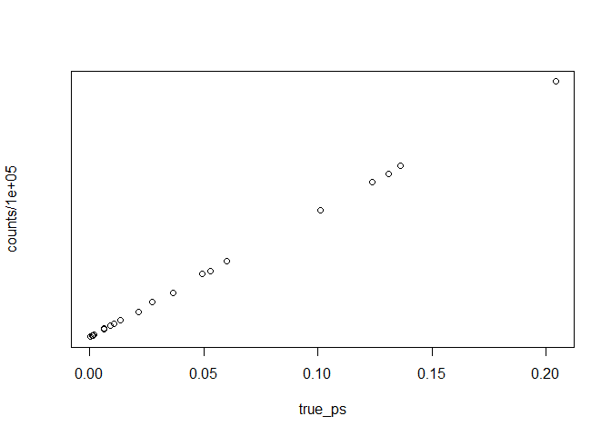

```r
true_multispecies_community <- sample(LETTERS, 1e5, replace = TRUE, prob = true_ps)

counts <- true_multispecies_community |> table()

plot(true_ps, counts/1e5)
```

do microbial ecologists ever calculate *preston plots*? do we?

the full community has the same distribution as the true vector.

Now to draw samples of different size from this true community

```r
# all samples of a different size
lib_size <- sample(100:7000, size = 35, replace = TRUE)

many_samples <- sapply(lib_size, function(x) sample(true_multispecies_community, size = x, replace = FALSE))

library(tidyverse)
```

```r
sample_df <- many_samples |> lapply(table) |>
  map_dfr(enframe, name = "ASV", value = "reads", .id = "sample_id") |>
  mutate(lib_size = lib_size[as.numeric(sample_id)],
         reads = as.numeric(reads))
```

look at the samples

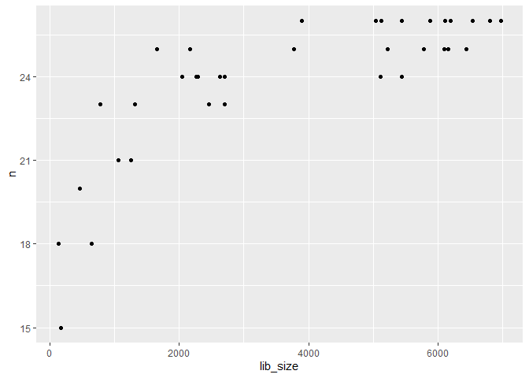

```r
sample_df |>
  count(lib_size) |>
  ggplot(aes(x = lib_size, y = n)) + geom_point()
```

Richness is different among samples of different size.

let’s look at observed relative abundance

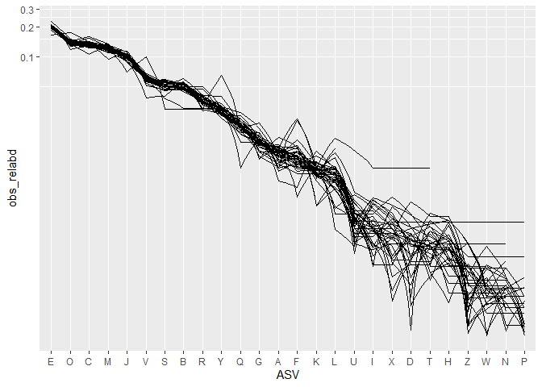

```r
sample_df |>
  mutate(obs_relabd = reads / lib_size,
         ASV = forcats::fct_reorder(ASV, obs_relabd, .desc = TRUE)) |>
  ggplot(aes(x = ASV, y = obs_relabd, group = sample_id)) +
  geom_line() +
  coord_trans(y = "log")
```

lots of variation

another way is a rank-abd plot:

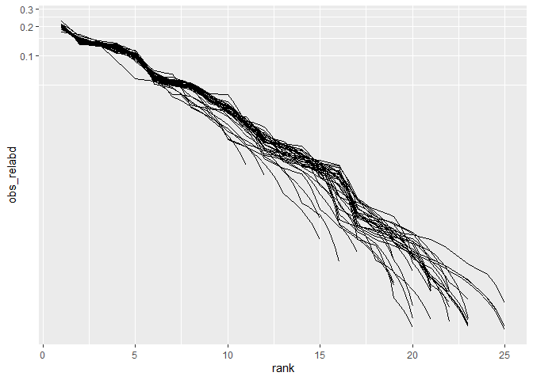

```r
sample_df |>
  group_by(sample_id) |>
  mutate(obs_relabd = reads / lib_size,
         rank = dense_rank(desc(obs_relabd))) |>
  ggplot(aes(x = rank, y = obs_relabd, group = sample_id)) +
  geom_line() +
  coord_trans(y = "log")
```

finally try with an offset Poisson:

```r
library(lme4)
multispp_mod <- glmer(reads ~ 1 + offset(log(lib_size)) + (1 | ASV), family = poisson(), data = sample_df)

summary(multispp_mod)
```

```
## Generalized linear mixed model fit by maximum likelihood (Laplace
##   Approximation) [glmerMod]
##  Family: poisson  ( log )
## Formula: reads ~ 1 + offset(log(lib_size)) + (1 | ASV)
##    Data: sample_df
##
##      AIC      BIC   logLik deviance df.resid
##   5441.2   5450.7  -2718.6   5437.2      831
##
## Scaled residuals:
##     Min      1Q  Median      3Q     Max
## -2.6253 -0.6085  0.0108  0.6170  3.4997
##
## Random effects:
##  Groups Name        Variance Std.Dev.
##  ASV    (Intercept) 4.195    2.048
## Number of obs: 833, groups:  ASV, 26
##
## Fixed effects:
##             Estimate Std. Error z value Pr(>|z|)
## (Intercept)  -4.7469     0.4019  -11.81   <2e-16 ***
## ---
## Signif. codes:  0 '***' 0.001 '**' 0.01 '*' 0.05 '.' 0.1 ' ' 1
```

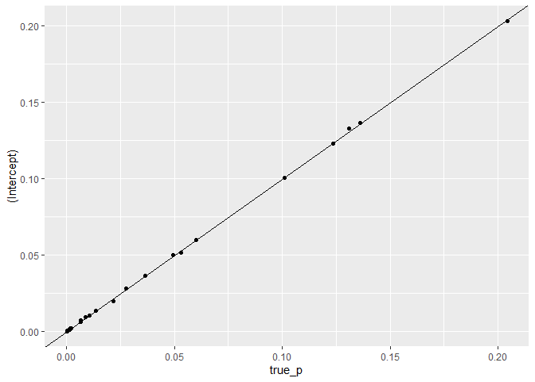

```r
empirical_prop <- exp(coef(multispp_mod)$ASV)


# get the true probs

true_w_names <- setNames(true_ps, LETTERS)

empirical_prop |>
  rownames_to_column(var = "ASV") |>
  mutate(true_p = true_w_names[ASV]) |>
  ggplot(aes(x = true_p, y = `(Intercept)`)) + geom_point() +
  geom_abline(slope = 1, intercept = 0)
```